# Module 6

Sankalp Biswal

2023-12-15

## 1.Importing Libraries

```r
library(tidyverse)
library(janitor)
library(dplyr)
library(magrittr)
```

## 2.Importing dataset

- Selecting variables of interest

```r
property_dataset <- read.csv("fy2023-property-assessment-data.csv")

property_subset <- subset(property_dataset,select = c(CITY,LU,LU_DESC,BLDG_TYPE,LAND_SF,GROSS_AREA,BLDG_VALUE,LAND_VALUE,TOTAL_VALUE,GROSS_TAX,YR_BUILT,YR_REMODEL,ROOF_STRUCTURE,BED_RMS,FULL_BTH,KITCHENS,TT_RMS,RES_FLOOR,OVERALL_COND,HEAT_TYPE,AC_TYPE,PROP_VIEW,NUM_PARKING,FIREPLACES,ZIP_CODE,LIVING_AREA))
```

## 3. Data cleaning

```r
clean_numeric_columns <- function(x) {
  # Remove outliers based on IQR
  q1 <- quantile(x, 0.25, na.rm = TRUE)
  q3 <- quantile(x, 0.75, na.rm = TRUE)
  iqr_value <- IQR(x, na.rm = TRUE)

  lower_bound <- q1 - 1.5 * iqr_value
  upper_bound <- q3 + 1.5 * iqr_value

  x_outliers_removed <- ifelse(x < lower_bound | x > upper_bound, NA, x)

  # Impute missing values with the median
  x_cleaned <- ifelse(is.na(x_outliers_removed), median(x, na.rm = TRUE), x_outliers_removed)

  return(x_cleaned)
}

# Clean all numeric columns in the dataset
property_subset_clean <- property_subset %>%
  mutate(across(where(is.numeric), clean_numeric_columns))

# Remove rows with any NA values after cleaning
property_subset_clean <- na.omit(property_subset_clean)

property_subset_clean <- property_subset_clean %>%
  mutate(CITY = ifelse(CITY == "" | is.na(CITY), "Unknown", CITY))

property_subset_clean <- property_subset_clean %>%
  mutate(OVERALL_COND = ifelse(OVERALL_COND == "" | is.na(OVERALL_COND), "Unknown", OVERALL_COND))

property_subset_clean <- property_subset_clean %>%
  mutate(PROP_VIEW = ifelse(PROP_VIEW == "" | is.na(PROP_VIEW), "Unknown", PROP_VIEW))

property_subset_clean <- property_subset_clean %>%
  mutate(AC_TYPE = ifelse(AC_TYPE == "" | is.na(AC_TYPE), "Unknown", AC_TYPE))

property_dataset <- clean_names(property_dataset)

property_extract <- subset(property_dataset, select = c("total_value", "living_area" ,"prop_view"))

property_extract <- na.omit(property_extract)

# Replace blank with NA
property_extract[property_extract == ""] <- NA

# Omit rows with missing values
property_extract <- na.omit(property_extract)
```

## 4. Tabulations

## Overview

- There are 2 parts namely - **PART-1 and PART-2**.
- **PART-1** deals with creation of dummy variables for the categorical variable “prop_view” and then running regression model for predicting total_value
- **PART-2** deals with creation of separate regression lines for predicting “total_value” using the subsetted data from PART-1.

## PART-1

- We create **dummy variables** for the **categorical variable** “prop_view”.
- We run the **regression model** for these **dummy variables** and **living area**.

```r
# Step 1: Create dummy variables for prop_view

df_dummies <- model.matrix(~ prop_view -1 , data = property_extract)  # -1 removes intercept term

# Step 2: Combine the dummy variables with the original dataset
df_combined <- cbind(property_extract["total_value"],property_extract["living_area"], df_dummies)

# Step 3: Run regression model

model <- lm(total_value ~ ., data = df_combined)

# Step 4: Print model summary
summary(model)
```

```
##
## Call:
## lm(formula = total_value ~ ., data = df_combined)
##
## Residuals:
##       Min        1Q    Median        3Q       Max
## -38245561   -267607     -2919    195729  33204493
##
## Coefficients: (1 not defined because of singularities)
##                            Estimate Std. Error t value Pr(>|t|)
## (Intercept)               4.576e+06  3.786e+04  120.87   <2e-16 ***
## living_area               4.243e+02  6.123e-01  692.92   <2e-16 ***
## `prop_viewA - Average`   -4.566e+06  3.788e+04 -120.55   <2e-16 ***
## `prop_viewE - Excellent` -3.246e+06  3.915e+04  -82.91   <2e-16 ***
## `prop_viewF - Fair`      -4.526e+06  3.879e+04 -116.70   <2e-16 ***
## `prop_viewG - Good`      -4.039e+06  3.830e+04 -105.43   <2e-16 ***
## `prop_viewP - Poor`      -4.460e+06  4.769e+04  -93.52   <2e-16 ***
## `prop_viewS - Special`           NA         NA      NA       NA
## ---
## Signif. codes:  0 '***' 0.001 '**' 0.01 '*' 0.05 '.' 0.1 ' ' 1
##
## Residual standard error: 666000 on 132341 degrees of freedom
## Multiple R-squared:  0.7957, Adjusted R-squared:  0.7957
## F-statistic: 8.589e+04 on 6 and 132341 DF,  p-value: < 2.2e-16
```

```r
# Step 5: Extract coefficients
coefficients <- coef(model)

# Step 6: Extract the number of subsets
num_subsets <- length(coefficients) - 1  # Exclude the intercept term

# Step 7: Extract the number of lines
num_lines <- nrow(df_combined)


# Step 8: Print the results
cat("Number of subsets:", num_subsets, "\n")
```

```
## Number of subsets: 7
```

```r
cat("Number of lines:", num_lines, "\n")
```

```
## Number of lines: 132348
```

## Model Summary:

1. **Residuals:** The residuals represent the differences between the observed and predicted values. The spread of residuals ranges from -38,245,561 to 33,204,493.
2. **Coefficients:** Coefficients indicate the estimated change in the dependent variable for a one-unit change in the predictor variable.
3. **Residual Standard Error:** The standard deviation of the residuals is 666,000, providing a measure of the typical distance between observed and predicted values.
4. **R-squared and Adjusted R-squared:** The R-squared is 0.7957, indicating that approximately 79.57% of the variability in total_value is explained by the model.
5. **Significance Levels:**
- P-values less than 0.001 (***): Highly significant
- P-values between 0.001 and 0.01 (**): Very significant
- P-values between 0.01 and 0.05 (*): Significant
- P-values between 0.05 and 0.1 (.): Marginally significant
6. **Coefficient Interpretation:**
1. **Intercept ((Intercept)):** Estimate: 4,576,000 Interpretation: When all predictor variables are zero, the estimated total_value is 4,576,000.
2. **living_area:** Estimate: 424.3 P-value: < 2e-16 (Highly significant) Interpretation: A one-unit increase in living area is associated with a highly significant increase of 424.3 units in total_value
3. **prop_viewA - Average:** Estimate: -4,566,000 P-value: < 2e-16 (Highly significant) Interpretation: Compared to the reference category (PROP_VIEWS - Special), the Average condition is associated with a highly significant decrease of 4,566,000 units in total_value
4. **prop_viewE - Excellent:** Estimate: -3,246,000 P-value: < 2e-16 (Highly significant) Interpretation: The Excellent condition has a highly significant negative impact, decreasing total_value by 3,246,000 units compared to the reference.
5. **prop_viewF - Fair:** Estimate: -4,526,000 P-value: < 2e-16 (Highly significant) Interpretation: The Fair condition decreases total_value by a highly significant 4,526,000 units compared to the reference.
6. **prop_viewG - Good:** Estimate: -4,039,000 P-value: < 2e-16 (Highly significant) Interpretation: The Good condition decreases total_value by a highly significant 4,039,000 units compared to the reference.
7. **prop_viewP - Poor:** Estimate: -4,460,000 P-value: < 2e-16 (Highly significant) Interpretation: The Poor condition decreases total_value by a highly significant 4,460,000 units compared to the reference.
8. **prop_viewS - Special:** Estimate: NA (Not defined due to singularities) P-value: NA Interpretation: This coefficient is not interpretable due to multicollinearity issues.

## Summary:

1. The model explains approximately **79.57%** of the variability in total_value.
2. Each **prop_view** category contributes significantly to the predicted **total_value**.
3. The living area is positively associated with an increase in **total_value**.
4. The model provides valuable insights into the factors influencing the total value of of the variability in **total_value**.

## Scatterplot with multiple regression lines

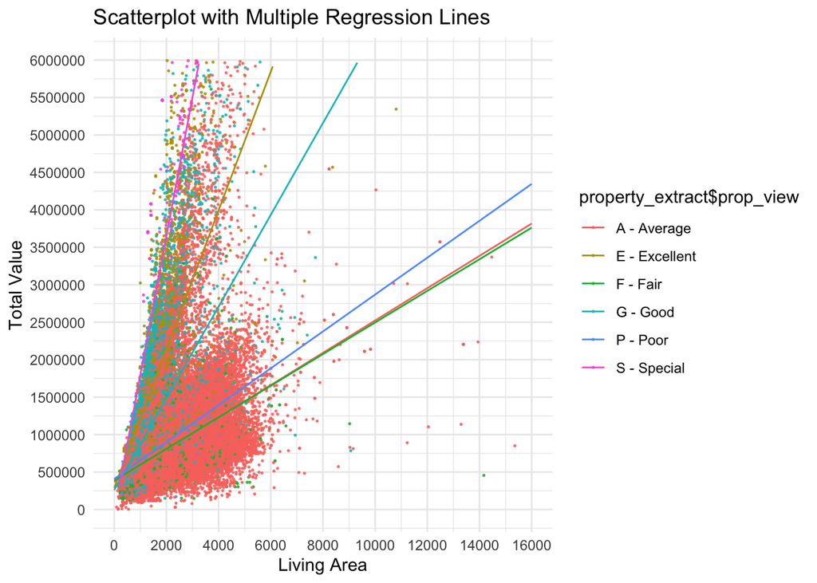

```r
# Step 8: Create a scatterplot with multiple regression lines
library(ggplot2)

options(scipen = 100, digits = 10)

ggplot(df_combined, aes(x = living_area, y = total_value, color = property_extract$prop_view)) +
  geom_point(size = 0.25, alpha = 0.8) +
  geom_smooth(method = "lm", se = FALSE, fullrange = TRUE ,size = 0.5) +  # Explicitly set group to 1
  labs(title = "Scatterplot with Multiple Regression Lines",
       x = "Living Area",
       y = "Total Value") +theme_minimal()+ scale_y_continuous(breaks = seq(0, 60000000, by = 500000), limits = c(0, 6000000)) + scale_x_continuous(breaks = seq(0, 16000, by = 2000),  limits = c(0, 16000))
```

```r
options(scipen = 0, digits = 7)
```

## Interpretation

1. **Points on the Scatterplot:**
- Each point on the scatterplot represents an observation in the dataset.
- The x-coordinate of each point represents the **living area** (living_area), and the y-coordinate represents the **total value** (total_value).
- The color of each point corresponds to the different levels of the categorical variable **prop_view**. Each color represents a different category or level of the variable.
- **Special** view has the steepest slope indicating that there is highest increase in total value per sqft living area for houses with this view.
- **Fair** view has the lowest slope indicating that there is lowest increase in total value per sqft living area for houses with this view.
2. **Regression Lines:**
- Each regression line represents the linear relationship between **living area** and **total value** for a specific category of **prop_view.**
- Since fullrange = TRUE, the lines extend across the entire range of the x-axis, giving us a sense of the overall trend.
3. **Interpretation of Regression Lines:**
- The slope of each regression line represents the average change in **total value** associated with a one-unit increase in **living area** for a specific category of **prop_view**.
- If the line **slopes upward**, it suggests a **positive relationship** between **living area** and **total value** for that **category**. If it **slopes downward**, it suggests a **negative relationship.**

## PART-2

- Now, we’ll plot the **regression line** for **each subset**.

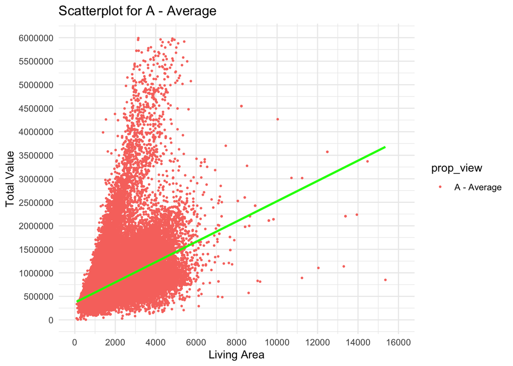

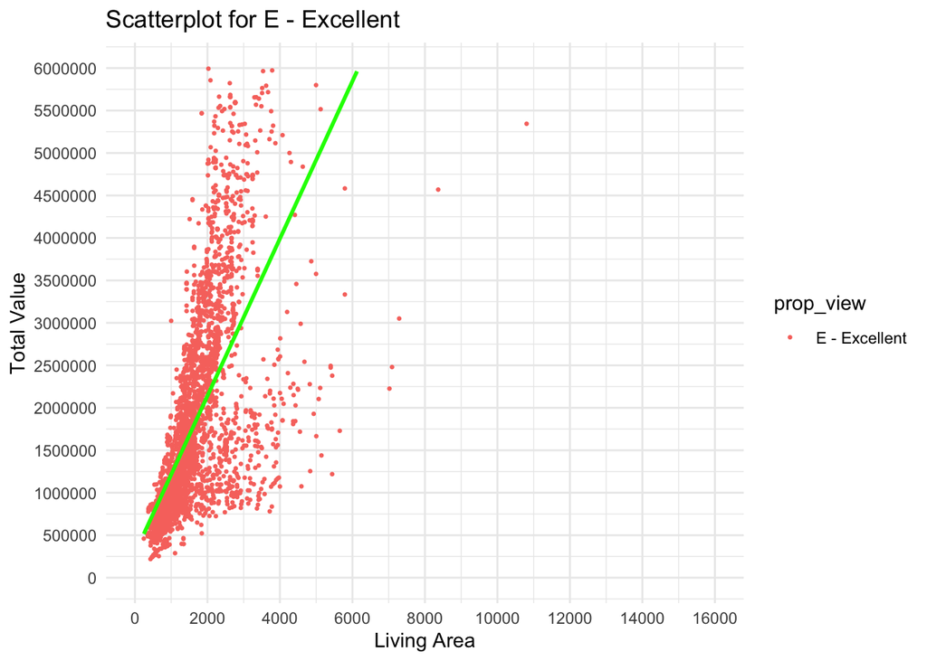

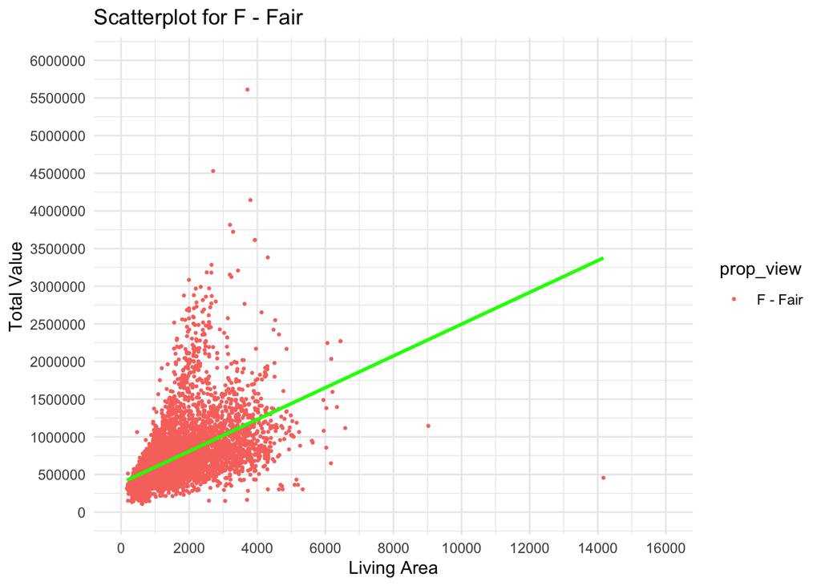

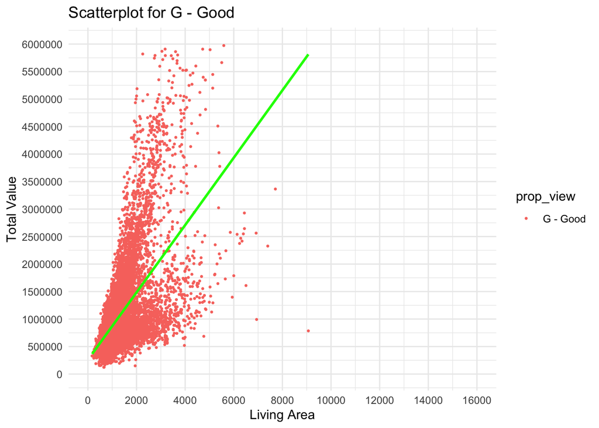

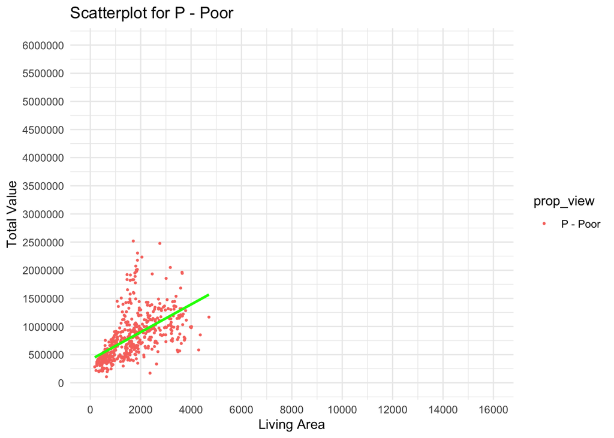

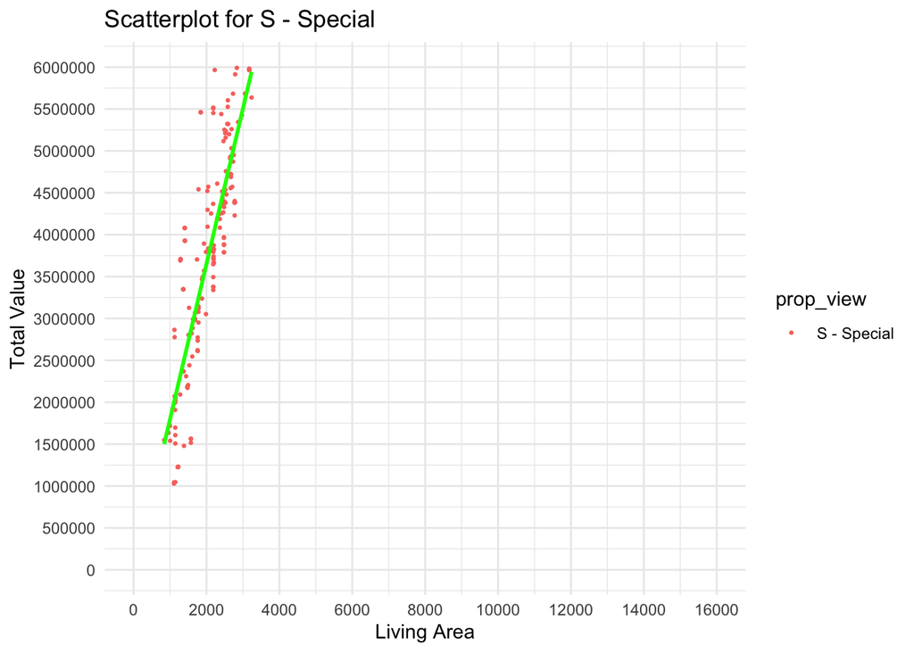

```r
options(scipen = 100, digits = 10)
# Assuming 'prop_view' is a factor variable
property_extract$prop_view <- as.factor(property_extract$prop_view)

# Fit separate linear regression models for each subset
regression_results <- property_extract %>%
  group_by(prop_view) %>%
  do(model = list(lm(total_value ~ living_area, data = .)))


# Create separate scatterplots with regression lines for each subset
for (i in seq_along(regression_results$model)) {
  level <- levels(property_extract$prop_view)[i]
  plot_data <- subset(property_extract, prop_view == level)

  individual_graph <- ggplot(data = plot_data, aes(x = living_area, y = total_value, color = prop_view)) +
    geom_point(size= 0.5) +
    geom_smooth(method = "lm", se = FALSE, color = "green") +
    labs(title = paste("Scatterplot for", level),
         x = "Living Area",
         y = "Total Value") +
    theme_minimal()+ scale_y_continuous(breaks = seq(0, 60000000, by = 500000), limits = c(0, 6000000)) + scale_x_continuous(breaks = seq(0, 16000, by = 2000),  limits = c(0, 16000))

  print(individual_graph)  # Use print() to display the plot
}
```

## Interpretation

1. Upon plotting individual graphs, we notice that the graphs for each **subset** are lot more **clearer**.
2. For **independent analysis** the individual graphs are better since points are more visible and have higher interpretability.
3. For **comparative analysis**, graph in PART-1 is better since we have all the graphs at one place.
4. **Point analysis** in the individual graphs is because in **PART-1** graph there’s an **overlap** between different **prop_view.**
5. There’s a **positive correlation** for all the above graphs.
6. **Average** and **Good** property views have densely populated scatterplot for smaller values indicating that value for houses with such view are lower.